# Data624_Hw2

Vijaya Cherukuri

9/12/2020

## Question 3.1

For the following series, find an appropriate Box-Cox transformation in order to stabilise the variance.

**Using side by side visualizations of the data i will try to answer the questions. The appropriate Box-Cox transformation will be on the right hand side with the lambda in the title.**

```r
side_by_side <- function(x, y){
  lambda <- BoxCox.lambda(x)
  plot1 <- autoplot(x) +
    ggtitle("Original") +
    ylab(y) +
    theme(axis.title.x = element_blank())
  plot2 <- autoplot(BoxCox(x, lambda)) +
    ggtitle(paste0("Box-Cox Transformed (lambda=", round(lambda, 4),")")) +
    theme(axis.title.x = element_blank(),
        axis.title.y = element_blank())
  grid.arrange(plot1, plot2, ncol = 2)
}
```

### usnetelec

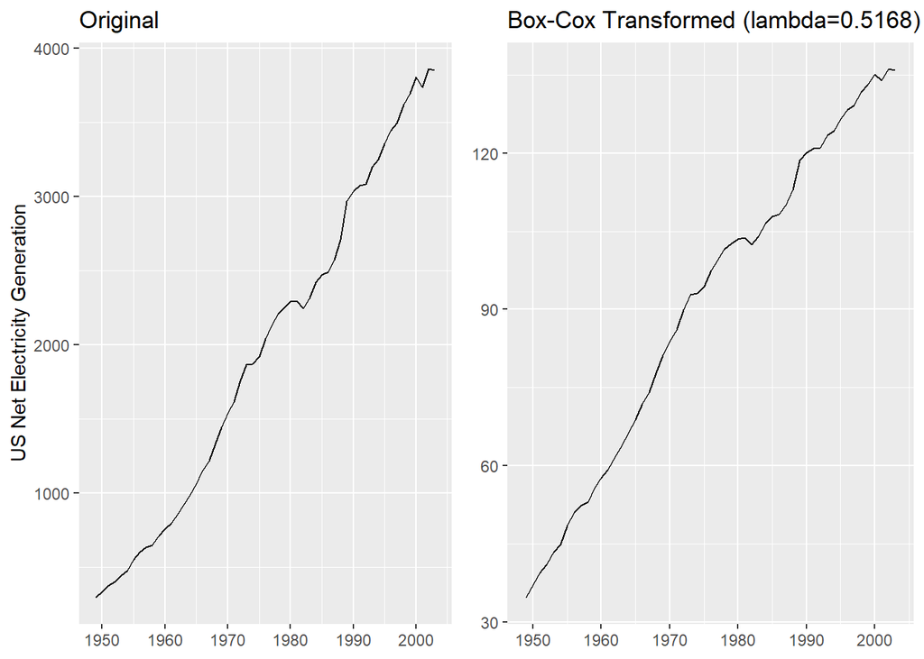

```r
side_by_side(usnetelec, "US Net Electricity Generation")
```

### usgdp

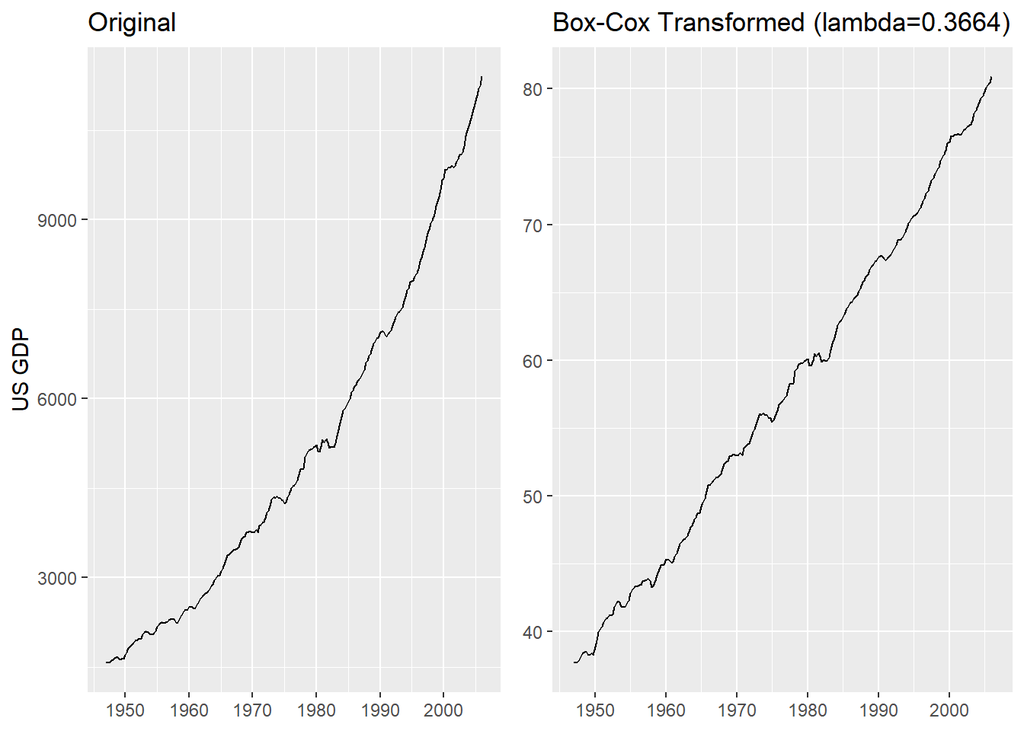

```r
side_by_side(usgdp, "US GDP")
```

### mcopper

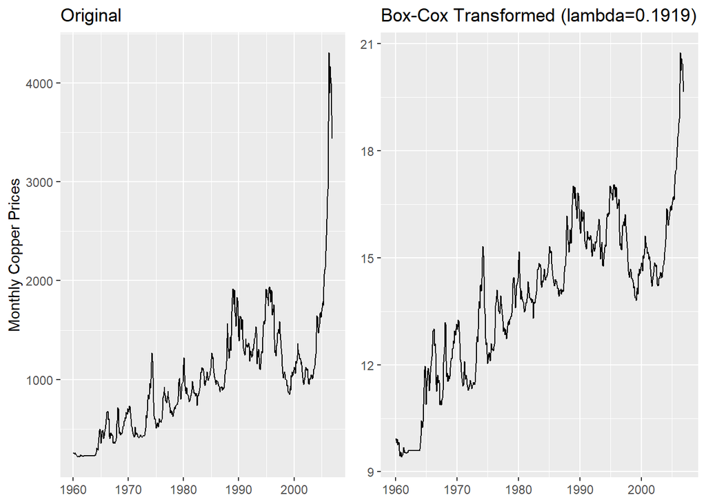

```r
side_by_side(mcopper, "Monthly Copper Prices")
```

### enplanements

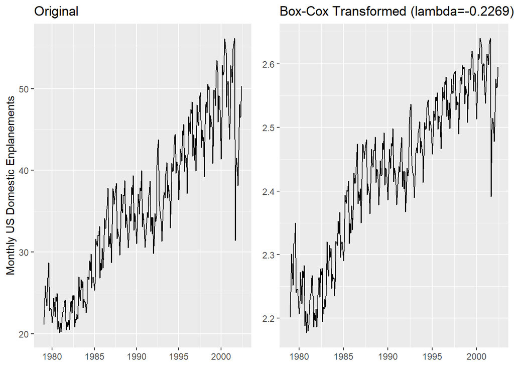

```r
side_by_side(enplanements, "Monthly US Domestic Enplanements")
```

## Question 3.2

Why is a Box-Cox transformation unhelpful for the `cangas` data?

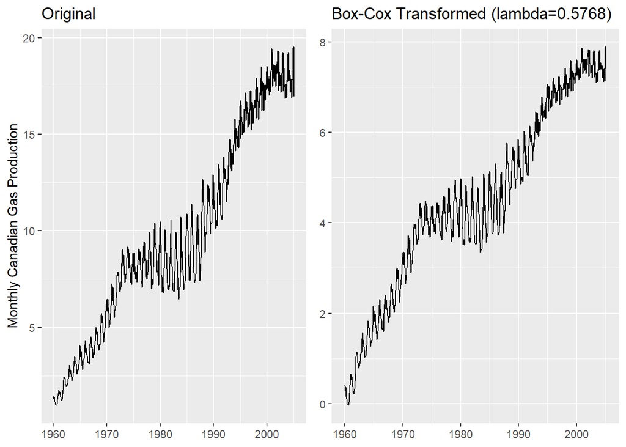

```r
side_by_side(cangas, "Monthly Canadian Gas Production")
```

**The Box-Cox transformation does not help with this timeseries because the variation is initially small, then gets large, then gets small again. Box-Cox was not designed to handle this case. It was designed for cases where the variance increases or decreases over time.**

## Question 3.3

What Box-Cox transformation would you select for your `retail` data?

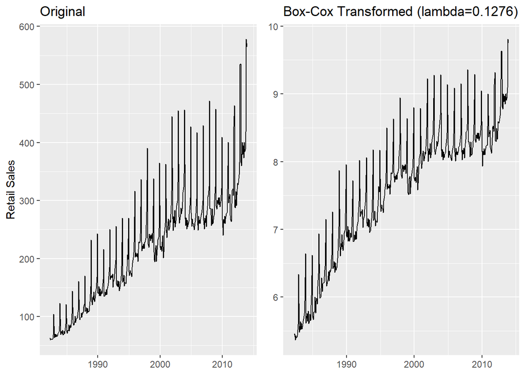

```r
temp = tempfile(fileext = ".xlsx")
dataURL <- "https://otexts.com/fpp2/extrafiles/retail.xlsx"
download.file(dataURL, destfile=temp, mode='wb')

retaildata <- readxl::read_excel(temp, skip=1)
myts <- ts(retaildata[, "A3349873A"], frequency = 12, start = c(1982, 4))
side_by_side(myts, "Retail Sales")
```

**The variation was increasing over time in the original data. It has become significantly more uniform once it is transformed with a lambda of 0.13. Because the variance was increasing over time this was an effective transformation.**

## Question 3.8

For your `retail` time series:

Split the data into two parts using

```r
myts.train <- window(myts, end = c(2010, 12))
myts.test <- window(myts, start = 2011)
```

Check that your data have been split appropriately by producing the following plot.

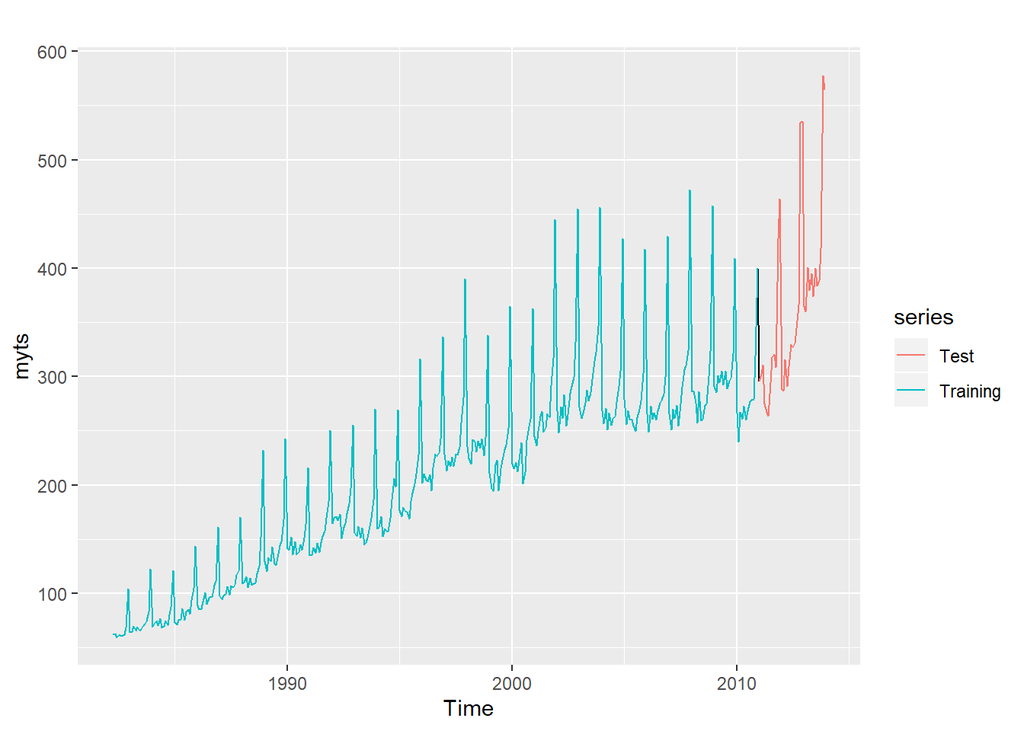

```r
autoplot(myts) +
  autolayer(myts.train, series = "Training") +
  autolayer(myts.test, series = "Test")
```

Calculate forecasts using snaive applied to myts.train.

```r
fc <- snaive(myts.train)
```

Compare the accuracy of your forecasts against the actual values stored in myts.test.

```r
accuracy(fc, myts.test)
```

```
                    ME     RMSE      MAE       MPE      MAPE     MASE      ACF1
Training set  7.772973 20.24576 15.95676  4.702754  8.109777 1.000000 0.7385090
Test set     55.300000 71.44309 55.78333 14.900996 15.082019 3.495907 0.5315239
             Theil's U
Training set        NA
Test set      1.297866
```

Check the residuals.

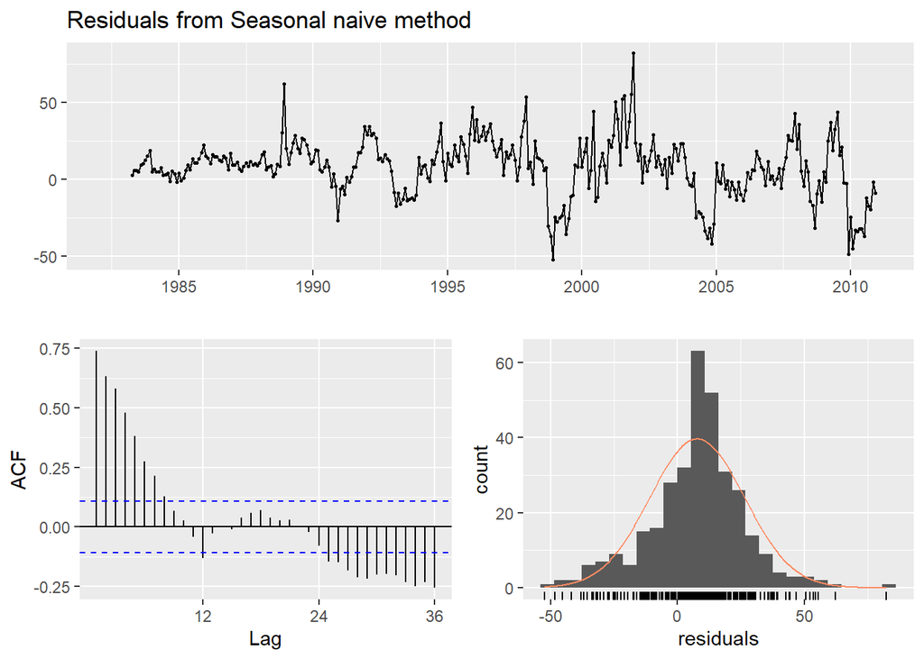

```
    Ljung-Box test

data:  Residuals from Seasonal naive method
Q* = 624.45, df = 24, p-value < 2.2e-16

Model df: 0.   Total lags used: 24
```

```r
checkresiduals(fc)
```

Do the residuals appear to be uncorrelated and normally distributed?

**They do appear to be normally distributed however with a sligh positve skew. The residuals do no appear to be uncorrelated. The Ljung-Box test has a p value that is less than 0.05. This suggests there is more information that can be discovered and that the seasonal naive model is not the best model.**

How sensitive are the accuracy measures to the training/test split?

**The accuracy measures are quite sensitive to the training/test split. The values are significantly different between the two. This would suggest that the model does not generalize well.**